# Final Project

Teresa Chen; Ting-fen Lin

5/12/2019

———-required packages———-

## What’s this project about?

The main purpose of the project is to calculate two outcome variables indicating human **joint-joint coordination** and **variability of coordination** during body movement. These two variables ared called *inter-joint continuous relative phase (CRP)* and *deviation phase (DP)*, respectily. They are widely used in the field of biomechanics, but to our knowlege there is no R function/package avalible designed for it.

### Description of data

The data was collected in the Motion Analysis Lab at UO. Five participants were recruited. They were asked to perform level walking on a 15-m straight walkway for a couple times. A 12-camera motion analysis system with a set of 40 reflective markers was used to record the whole body movement during walking (Figure 1, left). From the marker trajectories (Figure 1, middle), 3-D human model was created (Figure 1, right) and **joint data** was then calculated for further analysis.

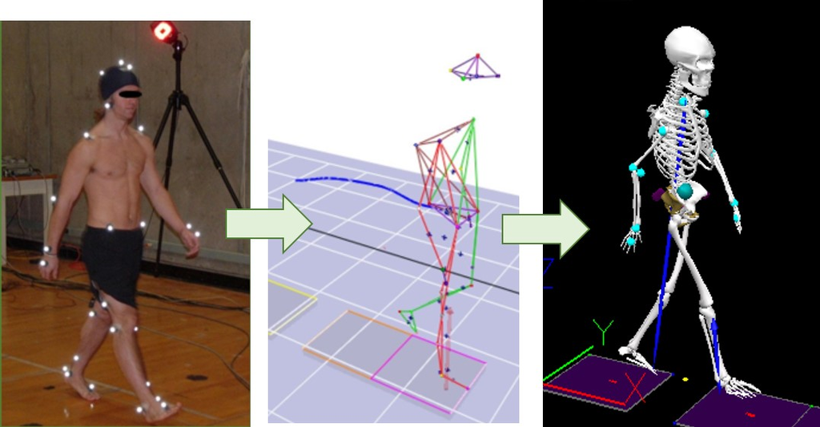

Figure 1

The goal of project is to create a shiny dashboard, which 1) prints the CRP and DP values, and 2) prints plots like Figure 2.

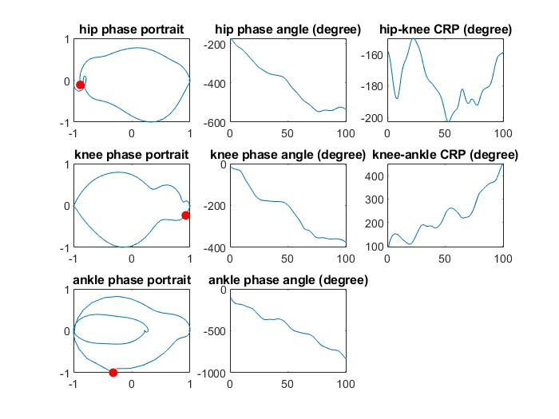

Figure 2

## Data Preparation

### Import data

```r
files <- dir_ls(here("data"), glob = "*.txt")
batch <- map_df(files, import, setclass = "tbl_df", .id = "file")
head(batch, 20L)
```

```
## # A tibble: 20 x 32
##    file   V1    V2    V3    V4    V5    V6    V7    V8    V9    V10   V11
##    <chr>  <chr> <chr> <chr> <chr> <chr> <chr> <chr> <chr> <chr> <chr> <chr>
##  1 /User… ""    F01W… F01W… F01W… F01W… F01W… F01W… F01W… F01W… F01W… F01W…
##  2 /User… ""    Righ… Righ… Righ… Righ… Righ… Righ… Righ… Righ… Righ… Righ…
##  3 /User… ""    LINK… LINK… LINK… LINK… LINK… LINK… LINK… LINK… LINK… LINK…
##  4 /User… ""    ORIG… ORIG… ORIG… ORIG… ORIG… ORIG… ORIG… ORIG… ORIG… ORIG…
##  5 /User… ITEM  Y     Y     Y     Y     Y     Y     Y     Y     Y     Y
##  6 /User… 1     -19.… 63.2… 7.11… 38.2… -6.5… 54.9… -17.… 16.4… 8.28… 82.6…
##  7 /User… 2     -19.… 72.5… 7.69… 40.2… -5.8… 82.1… -17.… 12.7… 9.27… 97.6…
##  8 /User… 3     -18.… 78.0… 8.35… 38.0… -4.7… 109.… -17.… 8.26… 10.4… 110.…
##  9 /User… 4     -17.… 78.5… 9.02… 37.0… -3.4… 129.… -16.… 3.99… 11.6… 120.…
## 10 /User… 5     -16.… 73.4… 9.70… 42.6… -1.9… 135.… -16.… 1.16… 12.9… 127.…
## 11 /User… 6     -15.… 63.5… 10.4… 56.9… -0.5… 125.… -16.… 0.88… 14.2… 130.…
## 12 /User… 7     -14.… 51.4… 11.2… 77.2… 0.64… 102.… -15.… 3.67… 15.4… 127.…
## 13 /User… 8     -13.… 40.3… 12.1… 97.4… 1.41… 71.5… -15.… 9.34… 16.6… 119.…
## 14 /User… 9     -13.… 33.2… 13.1… 111.… 1.76… 38.7… -15.… 17.1… 17.7… 107.…
## 15 /User… 10    -13.… 31.0… 14.1… 116.… 1.74… 8.72… -14.… 26.3… 18.6… 92.9…
## 16 /User… 11    -12.… 33.4… 15.1… 109.… 1.44… -15.… -14.… 35.8… 19.4… 77.3…
## 17 /User… 12    -12.… 38.9… 16.0… 93.3… 0.97… -33.… -13.… 45.2… 20.0… 61.0…
## 18 /User… 13    -12.… 45.9… 16.7… 70.0… 0.40… -46.… -13.… 54.3… 20.5… 43.9…
## 19 /User… 14    -11.… 53.3… 17.2… 43.2… -0.2… -54.… -12.… 63.0… 20.8… 25.8…
## 20 /User… 15    -10.… 61.0… 17.4… 15.9… -0.8… -60.… -12.… 71.4… 21.0… 7.19…
## # … with 20 more variables: V12 <chr>, V13 <chr>, V14 <chr>, V15 <chr>,
## #   V16 <chr>, V17 <chr>, V18 <chr>, V19 <chr>, V20 <chr>, V21 <chr>,
## #   V22 <chr>, V23 <chr>, V24 <chr>, V25 <chr>, V26 <chr>, V27 <chr>,
## #   V28 <chr>, V29 <chr>, V30 <chr>, V31 <chr>
```

The **bacth** has data from 5 subjects.

Each subject has upto 5 trials, representing 5 times of walking.

Each trial generates 6 outcome variables, including:

- **hip angle**
- **hip velocity**
- **knee angle**
- **knee velocity**
- **ankle angle**
- **ankle velocity**

Each variable has 101 datapoints (rows), representing 0%-100% of walking cycle.

There are couple issues to be solved before we can do the further analysis:

1. Column names (variable names) are meaningless. They are V1 to V31.
2. The first 4 rows of each iteration (subject) contain information we want:
- **trial**: from trial 1 upto trial 5.
- **outcome measurement**: angle or velocity of hip, knee, and ankle

### Tidy data

One function (tidy_for_v) is to

1. turn meaningless names to meaningful names, representing each **outcome measurement** and
2. extract **trial** information . It takes data of 1 measurment as input.

Another function (tidy_for_subject) is to apply aforementioned function to all meaningless variables (V2-V31). It takes data of 1 subject as input.

```r
##-----------function 01: tidy data, using 1 vector (measurement) as input-----##

tidy_for_v <- function(v){
  v <- v %>%
  mutate(var = value[2],
         trial = value[1],
         trial = str_replace_all(trial, ".c3d", ""),
         trial = str_replace_all(trial, "(......)_", ""),
         var = tolower(var)) %>%
  rename(frame = V1) %>%
  slice(-1:-5) %>%
  dplyr::select(trial, var, frame, value)
}


##------------function 02: tidy data, using 1 subject's data as input---------------##
##------------note: this function has another function(tidy_for_v) inside--------##

tidy_for_subject <- function(data){
  data_from_one_subject <- data %>%
    gather(temvar, value, V2:V31) %>%
    group_by(temvar) %>%
    nest() %>%
    mutate(tidy = map(data, tidy_for_v)) %>%
    dplyr::select(-data) %>%
    unnest()
}


tidy <- batch %>%
  mutate(file = str_replace_all(file, here("data"), ""),
         id = parse_number(file)) %>%
  select(id, everything(), -file) %>%
  group_by(id) %>%
  nest() %>%
  mutate(new_data = map(data, tidy_for_subject)) %>%
  dplyr::select(-data) %>%
  unnest() %>%
  dplyr::select(-temvar) %>%
  filter(!is.na(value)) %>%
  mutate(id = as.factor(id),
         trial = as.factor(trial),
         var = factor(var, levels = c("right_hip_angle", "right_hip_velocity",
                                      "right_knee_angle", "right_knee_velocity",
                                      "right_ankle_angle", "right_ankle_velocity"),
                      labels = c("hip angle", "hip velocity",
                                 "knee angle", "knee velocity",
                                 "ankle angle", "ankle velocity")),
         frame = as.factor(frame),
         value = as.numeric(value))


head(tidy, 20L)
```

```
## # A tibble: 20 x 5
##    id    trial var       frame  value
##    <fct> <fct> <fct>     <fct>  <dbl>
##  1 1     1     hip angle 1     -19.9
##  2 1     1     hip angle 2     -19.2
##  3 1     1     hip angle 3     -18.3
##  4 1     1     hip angle 4     -17.3
##  5 1     1     hip angle 5     -16.3
##  6 1     1     hip angle 6     -15.4
##  7 1     1     hip angle 7     -14.6
##  8 1     1     hip angle 8     -14.0
##  9 1     1     hip angle 9     -13.5
## 10 1     1     hip angle 10    -13.2
## 11 1     1     hip angle 11    -12.9
## 12 1     1     hip angle 12    -12.5
## 13 1     1     hip angle 13    -12.1
## 14 1     1     hip angle 14    -11.5
## 15 1     1     hip angle 15    -10.8
## 16 1     1     hip angle 16     -9.98
## 17 1     1     hip angle 17     -8.99
## 18 1     1     hip angle 18     -7.87
## 19 1     1     hip angle 19     -6.66
## 20 1     1     hip angle 20     -5.40
```

```r
str(tidy)
```

```
## Classes 'tbl_df', 'tbl' and 'data.frame':    14544 obs. of  5 variables:
##  $ id   : Factor w/ 5 levels "1","2","5","6",..: 1 1 1 1 1 1 1 1 1 1 ...
##  $ trial: Factor w/ 5 levels "1","2","3","4",..: 1 1 1 1 1 1 1 1 1 1 ...
##  $ var  : Factor w/ 6 levels "hip angle","hip velocity",..: 1 1 1 1 1 1 1 1 1 1 ...
##  $ frame: Factor w/ 101 levels "1","10","100",..: 1 14 25 36 47 58 69 80 91 2 ...
##  $ value: num  -19.9 -19.2 -18.3 -17.3 -16.3 ...
```